# Object size and model uncertainty — where to cut the minimum fire size

Step 06 · all fire-years · collection-01

Published

July 27, 2026

```r
knitr::opts_chunk$set(message = FALSE, warning = FALSE, dev = "png", dpi = 120)
# Every step-06 path is written from the repo ROOT. knitr restores the working directory after
# each chunk, so a setwd() in a later chunk would silently apply to that chunk only (and an
# unresolvable POLY_DIR yields an EMPTY table, not an error) — root.dir is the only thing that
# holds for the whole render.
knitr::opts_knit$set(root.dir = normalizePath(if (dir.exists("collection-01")) "." else "../.."))
library(data.table)
library(ggplot2)
library(patchwork)
library(knitr)
theme_set(theme_bw(base_size = 11) +
          theme(panel.grid.minor = element_blank(),
                strip.background = element_rect(fill = "grey92", colour = NA)))
```

```r
source("collection-01/scripts/objects_data_functions.R")
PRED_DIR <- "collection-01/data/objects-predictions"
```

## Why this notebook

```r
years <- object_years()
if (!length(years)) stop("no step-05 raster_metrics CSVs under ", POLY_DIR,
                         " (wd = ", getwd(), ") — nothing to summarise")
sizes <- rbindlist(lapply(years, function(fy) {
  d <- fread(file.path(POLY_DIR, sprintf("objects_%d_raster_metrics.csv", fy)),
             select = c("oid", "n_pixels", "area_ha"))
  d[, fire_year := fy][]
}))
# set(), not `:=`: the column and the helper share a name, and inside data.table's j-scope the
# argument promise fails to resolve under knitr's eval frame
set(sizes, j = "size_class", value = size_class(sizes$area_ha))
cat(sprintf("%s objects, fire-years %d-%d, %.2f Mha total\n",
            format(nrow(sizes), big.mark = ","), min(years), max(years),
            sum(sizes$area_ha) / 1e6))
```

```
1,689,419 objects, fire-years 1998-2025, 84.99 Mha total
```

## 1 · How the objects and the area split by size

`size_class` uses the **display** breaks (0.5, 1, 50, 300, 1000 ha) — six classes. These are not the four threshold bands: `<0.5` / `0.5-1` exist only because the minimum-size decision lives inside them, and `300-1000` / `>=1000` because we want to see whether the very large objects behave apart (the threshold work found they do not, statistically).

```r
tab <- sizes[, .(n = .N, area_kha = sum(area_ha) / 1e3), by = size_class][order(size_class)]
tab[, `:=`(pct_n = 100 * n / sum(n), pct_area = 100 * area_kha / sum(area_kha))]
tab[, `:=`(cum_pct_n = cumsum(pct_n), cum_pct_area = cumsum(pct_area))]
kable(tab, digits = c(0, 0, 1, 2, 3, 2, 3), format.args = list(big.mark = ","),
      col.names = c("size class", "objects", "area (kha)", "% objects", "% area",
                    "cum % objects", "cum % area"),
      caption = "Objects and area by display size class, all fire-years pooled.")
```

Objects and area by display size class, all fire-years pooled.

| size class | objects | area (kha) | % objects | % area | cum % objects | cum % area |
| --- | --- | --- | --- | --- | --- | --- |
| <0.5 ha | 15,103 | 4.0 | 0.89 | 0.005 | 0.89 | 0.005 |
| 0.5-1 ha | 42,516 | 33.5 | 2.52 | 0.039 | 3.41 | 0.044 |
| 1-50 ha | 1,409,245 | 16,786.9 | 83.42 | 19.751 | 86.83 | 19.795 |
| 50-300 ha | 192,380 | 20,465.2 | 11.39 | 24.079 | 98.21 | 43.875 |
| 300-1000 ha | 22,791 | 11,534.3 | 1.35 | 13.571 | 99.56 | 57.446 |
| >=1000 ha | 7,384 | 36,167.1 | 0.44 | 42.554 | 100.00 | 100.000 |

The asymmetry between the two “%” columns is the whole story of a minimum-size cut: it buys a large reduction in object count for a small loss of area. The `cum %` columns read directly as “if I cut here, I discard this many objects and this much area”.

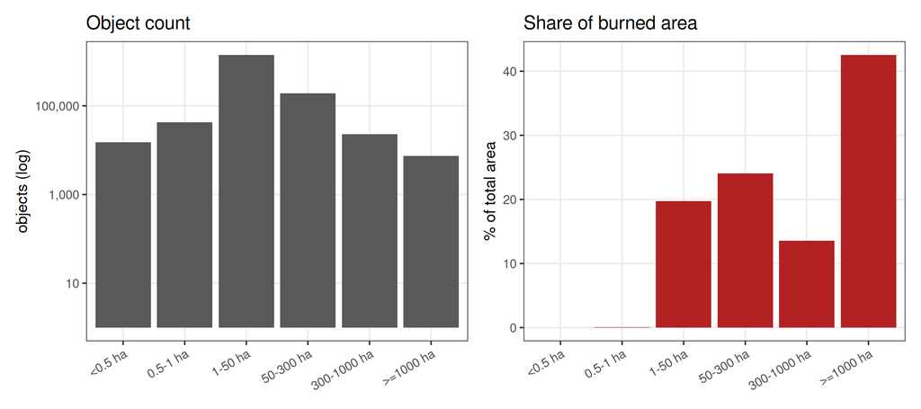

```r
p1 <- ggplot(tab, aes(size_class, n)) +
  geom_col(fill = "grey35") + scale_y_log10(labels = scales::comma) +
  labs(x = NULL, y = "objects (log)", title = "Object count") +
  theme(axis.text.x = element_text(angle = 30, hjust = 1))
p2 <- ggplot(tab, aes(size_class, pct_area)) +
  geom_col(fill = "firebrick") +
  labs(x = NULL, y = "% of total area", title = "Share of burned area") +
  theme(axis.text.x = element_text(angle = 30, hjust = 1))
p1 + p2
```

## 2 · The pixel scale — what “<1 ha” actually means

Areas are **not** on a 0.09 ha grid. The objects carry lat/lon pixel coordinates — ~30 m *at the equator* — and area is measured on the ellipsoid, so one pixel is `900 * cos(lat)` m²: 831 m² in Formosa, 517 m² in southern Santa Cruz. Harmless, but it means a sub-hectare class is a pixel-count **range**, not a fixed count, and the same 15-pixel object is `>=1 ha` in the north and `<1 ha` in Patagonia.

```r
sizes[, px_ha := area_ha / n_pixels]
pxq <- sizes[, .(min = min(px_ha), q05 = quantile(px_ha, .05), median = median(px_ha),
                 q95 = quantile(px_ha, .95), max = max(px_ha))]
kable(round(pxq * 1e4, 1), col.names = c("min", "q05", "median", "q95", "max"),
      caption = "Per-pixel ground area (m²) across the country.")
```

Per-pixel ground area (m²) across the country.

| min | q05 | median | q95 | max |
| --- | --- | --- | --- | --- |
| 516.7 | 701.2 | 777.9 | 812.3 | 831.3 |

```r
cat(sprintf("0.5 ha = %.0f-%.0f pixels   |   1 ha = %.0f-%.0f pixels\n",
            0.5 / max(sizes$px_ha), 0.5 / min(sizes$px_ha),
            1 / max(sizes$px_ha), 1 / min(sizes$px_ha)))
```

```
0.5 ha = 6-10 pixels   |   1 ha = 12-19 pixels
```

What *does* bound the sub-hectare decision is that these objects have almost no measurable geometry: convexity, circularity and `shape_index` on a 4-pixel blob are close to meaningless, so the model is working almost entirely from spectral/context predictors there.

```r
q <- sizes[n_pixels <= 24, .(objects = .N, area_ha_range = sprintf("%.2f-%.2f", min(area_ha),
                                                                   max(area_ha))),
           by = n_pixels][order(n_pixels)]
kable(q, format.args = list(big.mark = ","),
      col.names = c("pixels", "objects", "area range (ha)"),
      caption = "The smallest objects by pixel count, with the latitude-driven area spread.")
```

The smallest objects by pixel count, with the latitude-driven area spread.

| pixels | objects | area range (ha) |
| --- | --- | --- |
| 1 | 3,796 | 0.05-0.08 |
| 2 | 2,493 | 0.10-0.17 |
| 3 | 1,344 | 0.16-0.25 |
| 4 | 1,165 | 0.21-0.33 |
| 5 | 778 | 0.26-0.41 |
| 6 | 3,081 | 0.31-0.50 |
| 7 | 3,766 | 0.36-0.58 |
| 8 | 4,738 | 0.41-0.66 |
| 9 | 5,487 | 0.47-0.75 |
| 10 | 6,566 | 0.52-0.83 |
| 11 | 7,572 | 0.57-0.91 |
| 12 | 8,891 | 0.62-1.00 |
| 13 | 9,532 | 0.67-1.08 |
| 14 | 10,602 | 0.73-1.16 |
| 15 | 11,335 | 0.78-1.25 |
| 16 | 11,636 | 0.83-1.33 |
| 17 | 11,996 | 0.88-1.41 |
| 18 | 12,434 | 0.93-1.49 |
| 19 | 12,443 | 0.98-1.58 |
| 20 | 12,474 | 1.04-1.66 |
| 21 | 12,670 | 1.09-1.74 |
| 22 | 12,680 | 1.14-1.83 |
| 23 | 12,408 | 1.19-1.91 |
| 24 | 12,444 | 1.24-1.99 |

Note the shape of that count column: it **dips** from 3796 one-pixel objects to 778 at five pixels, then climbs monotonically (6 px → 3081, 20 px → 12474). A segmentation floor would produce a hard cut, not a dip-then-rise, so something is producing isolated 1-2 pixel objects that the 3-5 pixel range does not get. The step-05 1-pixel dilation connectivity hack (docs/05) is the obvious suspect. Worth a look in QGIS — it is a small share of area either way.

```r
sub <- sizes[area_ha < 1]
cat(sprintf(
  "\nSub-hectare objects: **%s** (%.2f %% of objects) holding **%.1f kha** (%.3f %% of area). ",
  format(nrow(sub), big.mark = ","), 100 * nrow(sub) / nrow(sizes),
  sum(sub$area_ha) / 1e3, 100 * sum(sub$area_ha) / sum(sizes$area_ha)))
```

Sub-hectare objects: **57,619** (3.41 % of objects) holding **37.5 kha** (0.044 % of area).

```r
cat(sprintf("Of these, %s are a **single pixel** (%.1f %% of the sub-hectare set).\n",
            format(sum(sub$n_pixels == 1L), big.mark = ","),
            100 * mean(sub$n_pixels == 1L)))
```

Of these, 3,796 are a **single pixel** (6.6 % of the sub-hectare set).

## 3 · The expanded distribution

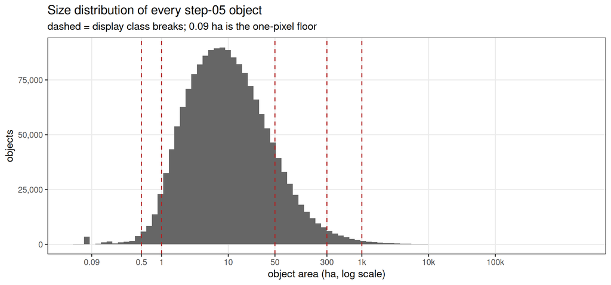

```r
brk <- SIZE_BREAKS_VIEW[is.finite(SIZE_BREAKS_VIEW) & SIZE_BREAKS_VIEW > 0]
ggplot(sizes, aes(area_ha)) +
  geom_histogram(bins = 90, fill = "grey40") +
  geom_vline(xintercept = brk, colour = "firebrick", linetype = 2) +
  scale_x_log10(breaks = c(.09, .5, 1, 10, 50, 300, 1e3, 1e4, 1e5),
                labels = c("0.09", "0.5", "1", "10", "50", "300", "1k", "10k", "100k")) +
  scale_y_continuous(labels = scales::comma) +
  labs(x = "object area (ha, log scale)", y = "objects",
       title = "Size distribution of every step-05 object",
       subtitle = "dashed = display class breaks; 0.09 ha is the one-pixel floor")
```

## 4 · Is the small-object share stable across years?

If the sub-hectare fraction jumped around by year, a single global minimum size would be the wrong instrument. If it is stable, one cut is defensible.

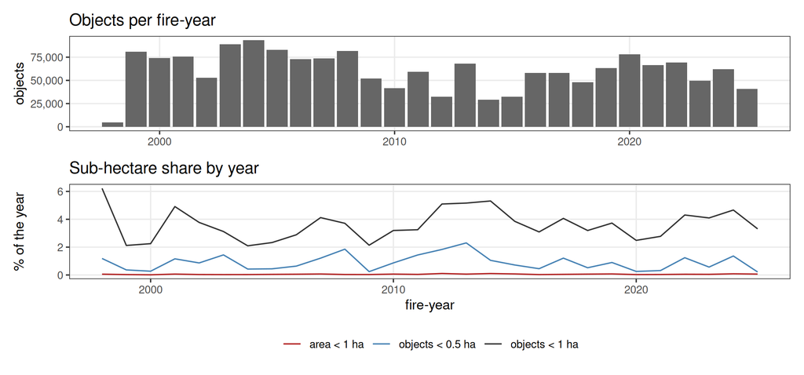

```r
yr <- sizes[, .(n = .N, area_kha = sum(area_ha) / 1e3,
                pct_n_lt1    = 100 * mean(area_ha < 1),
                pct_area_lt1 = 100 * sum(area_ha[area_ha < 1]) / sum(area_ha),
                pct_n_lt05   = 100 * mean(area_ha < 0.5)), by = fire_year][order(fire_year)]
py1 <- ggplot(yr, aes(fire_year)) +
  geom_col(aes(y = n), fill = "grey40") + scale_y_continuous(labels = scales::comma) +
  labs(x = NULL, y = "objects", title = "Objects per fire-year")
py2 <- ggplot(yr, aes(fire_year)) +
  geom_line(aes(y = pct_n_lt1, colour = "objects < 1 ha")) +
  geom_line(aes(y = pct_n_lt05, colour = "objects < 0.5 ha")) +
  geom_line(aes(y = pct_area_lt1, colour = "area < 1 ha")) +
  scale_colour_manual(NULL, values = c("objects < 1 ha" = "grey20",
                                       "objects < 0.5 ha" = "steelblue",
                                       "area < 1 ha" = "firebrick")) +
  labs(x = "fire-year", y = "% of the year", title = "Sub-hectare share by year") +
  theme(legend.position = "bottom")
py1 / py2
```

```r
kable(yr, digits = c(0, 0, 1, 2, 3, 2), format.args = list(big.mark = ","),
      col.names = c("fire-year", "objects", "area (kha)", "% obj <1 ha", "% area <1 ha",
                    "% obj <0.5 ha"),
      caption = "Per-year totals and sub-hectare shares.")
```

Per-year totals and sub-hectare shares.

| fire-year | objects | area (kha) | % obj <1 ha | % area <1 ha | % obj <0.5 ha |
| --- | --- | --- | --- | --- | --- |
| 1,998 | 4,805 | 361.0 | 6.22 | 0.058 | 1.19 |
| 1,999 | 80,925 | 3,906.7 | 2.12 | 0.031 | 0.36 |
| 2,000 | 74,147 | 8,492.4 | 2.25 | 0.015 | 0.27 |
| 2,001 | 75,629 | 3,838.5 | 4.91 | 0.065 | 1.16 |
| 2,002 | 52,796 | 3,883.4 | 3.77 | 0.034 | 0.87 |
| 2,003 | 88,931 | 4,938.2 | 3.12 | 0.029 | 1.44 |
| 2,004 | 93,154 | 4,282.8 | 2.10 | 0.031 | 0.43 |
| 2,005 | 83,076 | 3,051.6 | 2.33 | 0.045 | 0.44 |
| 2,006 | 72,946 | 2,616.3 | 2.89 | 0.055 | 0.64 |
| 2,007 | 73,561 | 2,641.6 | 4.12 | 0.072 | 1.21 |
| 2,008 | 81,723 | 4,220.5 | 3.71 | 0.036 | 1.85 |
| 2,009 | 52,170 | 2,519.6 | 2.14 | 0.033 | 0.24 |
| 2,010 | 41,484 | 1,334.0 | 3.20 | 0.064 | 0.87 |
| 2,011 | 59,100 | 2,406.8 | 3.25 | 0.043 | 1.44 |
| 2,012 | 32,209 | 905.7 | 5.10 | 0.107 | 1.83 |
| 2,013 | 68,002 | 2,999.3 | 5.16 | 0.063 | 2.30 |
| 2,014 | 29,294 | 1,036.0 | 5.32 | 0.104 | 1.05 |
| 2,015 | 32,483 | 1,125.6 | 3.85 | 0.076 | 0.72 |
| 2,016 | 57,955 | 4,329.6 | 3.09 | 0.030 | 0.45 |
| 2,017 | 57,923 | 3,202.0 | 4.06 | 0.046 | 1.21 |
| 2,018 | 47,927 | 1,774.5 | 3.19 | 0.062 | 0.52 |
| 2,019 | 63,069 | 2,061.8 | 3.73 | 0.076 | 0.90 |
| 2,020 | 78,217 | 4,840.5 | 2.49 | 0.031 | 0.26 |
| 2,021 | 66,393 | 3,859.8 | 2.77 | 0.036 | 0.32 |
| 2,022 | 69,221 | 3,532.3 | 4.31 | 0.053 | 1.24 |
| 2,023 | 49,432 | 3,115.6 | 4.10 | 0.047 | 0.57 |
| 2,024 | 62,170 | 2,132.5 | 4.66 | 0.085 | 1.36 |
| 2,025 | 40,677 | 1,582.1 | 3.31 | 0.065 | 0.22 |

## 5 · The labelled data by size and class

Where the labels are is where the model has evidence. This is the constraint on any size-specific claim, including the thresholds.

```r
tag <- clean_tagged(verbose = FALSE)
set(tag, j = "size_class", value = size_class(tag$area_ha))
lt <- dcast(tag[, .N, by = .(size_class, class)], size_class ~ class,
            value.var = "N", fill = 0L, drop = FALSE)
setnames(lt, c("0", "1"), c("non-fire", "fire"), skip_absent = TRUE)
lt[, total := `non-fire` + fire][, prevalence := round(fire / total, 3)]
kable(lt, format.args = list(big.mark = ","),
      caption = "Labelled objects by size class and class (the fitting set, 5255 objects).")
```

Labelled objects by size class and class (the fitting set, 5255 objects).

| size_class | non-fire | fire | total | prevalence |
| --- | --- | --- | --- | --- |
| <0.5 ha | 29 | 1 | 30 | 0.033 |
| 0.5-1 ha | 56 | 28 | 84 | 0.333 |
| 1-50 ha | 1,710 | 1,507 | 3,217 | 0.468 |
| 50-300 ha | 506 | 686 | 1,192 | 0.576 |
| 300-1000 ha | 100 | 299 | 399 | 0.749 |
| >=1000 ha | 66 | 267 | 333 | 0.802 |

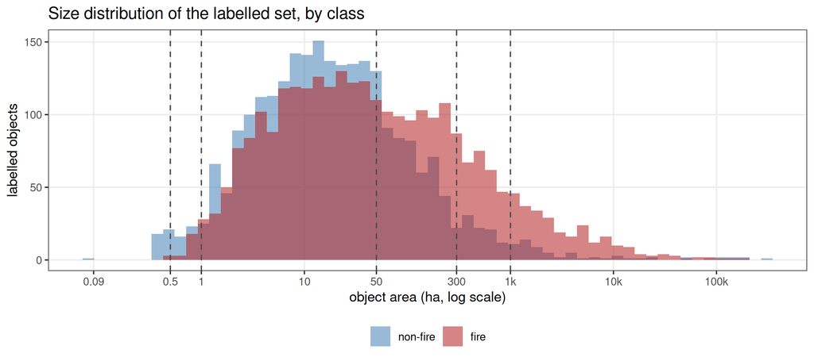

```r
ggplot(tag, aes(area_ha, fill = factor(class, 0:1, c("non-fire", "fire")))) +
  geom_histogram(bins = 60, position = "identity", alpha = .55) +
  geom_vline(xintercept = brk, colour = "grey30", linetype = 2) +
  scale_x_log10(breaks = c(.09, .5, 1, 10, 50, 300, 1e3, 1e4, 1e5),
                labels = c("0.09", "0.5", "1", "10", "50", "300", "1k", "10k", "100k")) +
  scale_fill_manual(NULL, values = c("non-fire" = "steelblue", "fire" = "firebrick")) +
  labs(x = "object area (ha, log scale)", y = "labelled objects",
       title = "Size distribution of the labelled set, by class") +
  theme(legend.position = "bottom")
```

```r
cmp <- merge(sizes[, .(all_pct = 100 * .N / nrow(sizes)), by = size_class],
             tag[, .(lab_pct = 100 * .N / nrow(tag)), by = size_class],
             by = "size_class", all.x = TRUE)[order(size_class)]
cmp[is.na(lab_pct), lab_pct := 0]
kable(cmp, digits = 2, col.names = c("size class", "% of all objects", "% of labels"),
      caption = "Labels are NOT a size-representative sample of the objects.")
```

Labels are NOT a size-representative sample of the objects.

| size class | % of all objects | % of labels |
| --- | --- | --- |
| <0.5 ha | 0.89 | 0.57 |
| 0.5-1 ha | 2.52 | 1.60 |
| 1-50 ha | 83.42 | 61.22 |
| 50-300 ha | 11.39 | 22.68 |
| 300-1000 ha | 1.35 | 7.59 |
| >=1000 ha | 0.44 | 6.34 |

## 6 · Model probability and uncertainty

```r
pf <- list.files(PRED_DIR, pattern = "^objects_[0-9]{4}_pred\\.csv$", full.names = TRUE)
pred_years <- sort(as.integer(sub("^objects_([0-9]{4}).*$", "\\1", basename(pf))))
HAS_PREDS  <- length(pred_years) > 0L
COMPLETE   <- setequal(pred_years, years)
```

```r
if (!HAS_PREDS) {
  cat("::: {.callout-warning}\n## No predictions yet\n",
      "Run `Rscript collection-01/workflow/06-object_model.R predict all` (~37 min, tmux),",
      "then re-render. Sections 1-5 above are complete and do not depend on it.\n:::\n")
} else if (!COMPLETE) {
  cat(sprintf("::: {.callout-warning}\n## Partial predictions\n%d of %d fire-years scored (%s).%s\n:::\n",
      length(pred_years), length(years), paste(range(pred_years), collapse = "-"),
      " Everything below covers only those years."))
} else {
  cat(sprintf("All %d fire-years scored.\n", length(pred_years)))
}
```

All 28 fire-years scored.

```r
pr <- rbindlist(lapply(pf, fread))
d  <- merge(sizes, pr[, .(oid, p_mean, p_sd, p_q05, p_q95, p_width)], by = "oid")
d  <- cbind(d, apply_thresholds(d$area_ha, d$p_mean))
# "undecided": the posterior interval straddles the cut that applies to this object, i.e. the
# model cannot place it on either side at the 5-95 % level. This is the uncertainty measure that
# speaks to a minimum-size decision — unlike p_width, it is relative to the decision being made.
d[, undecided := p_q05 < p_thresh & p_q95 > p_thresh]
cat(sprintf("%s scored objects joined (%s unscored: NA predictors)\n",
            format(sum(!is.na(d$p_mean)), big.mark = ","),
            format(sum(is.na(d$p_mean)), big.mark = ",")))
```

```
1,689,383 scored objects joined (36 unscored: NA predictors)
```

### 6.1 By size class

```r
ps <- d[!is.na(p_mean), .(
  n            = .N,
  area_kha     = sum(area_ha) / 1e3,
  p_thresh     = first(p_thresh),
  med_p        = round(median(p_mean), 3),
  mean_width   = round(mean(p_width), 3),
  med_width    = round(median(p_width), 3),
  pct_fire     = round(100 * mean(fire == 1L), 1),
  pct_area_fire= round(100 * sum(area_ha[fire == 1L]) / sum(area_ha), 1),
  pct_undecided= round(100 * mean(undecided), 1)), by = size_class][order(size_class)]
kable(ps, format.args = list(big.mark = ","),
      col.names = c("size class", "objects", "area (kha)", "cut", "median p", "mean width",
                    "median width", "% called fire", "% area called fire", "% undecided"),
      caption = "Model output by size class. 'cut' is the deployed threshold for that class; '% undecided' = the p_q05-p_q95 interval straddles it.")
```

Model output by size class. ‘cut’ is the deployed threshold for that class; ‘% undecided’ = the p_q05-p_q95 interval straddles it.

| size class | objects | area (kha) | cut | median p | mean width | median width | % called fire | % area called fire | % undecided |
| --- | --- | --- | --- | --- | --- | --- | --- | --- | --- |
| <0.5 ha | 15,070 | 4.003399 | 0.2330 | 0.092 | 0.395 | 0.363 | 26.3 | 29.7 | 58.8 |
| 0.5-1 ha | 42,514 | 33.507577 | 0.2330 | 0.352 | 0.476 | 0.513 | 59.9 | 60.8 | 58.3 |
| 1-50 ha | 1,409,244 | 16,786.851402 | 0.1802 | 0.415 | 0.418 | 0.444 | 69.4 | 69.8 | 46.6 |
| 50-300 ha | 192,380 | 20,465.167019 | 0.4051 | 0.613 | 0.399 | 0.410 | 63.1 | 66.2 | 42.5 |
| 300-1000 ha | 22,791 | 11,534.317751 | 0.5981 | 0.894 | 0.329 | 0.287 | 75.5 | 76.9 | 36.8 |
| >=1000 ha | 7,384 | 36,167.077432 | 0.5981 | 0.968 | 0.235 | 0.130 | 88.1 | 88.6 | 24.0 |

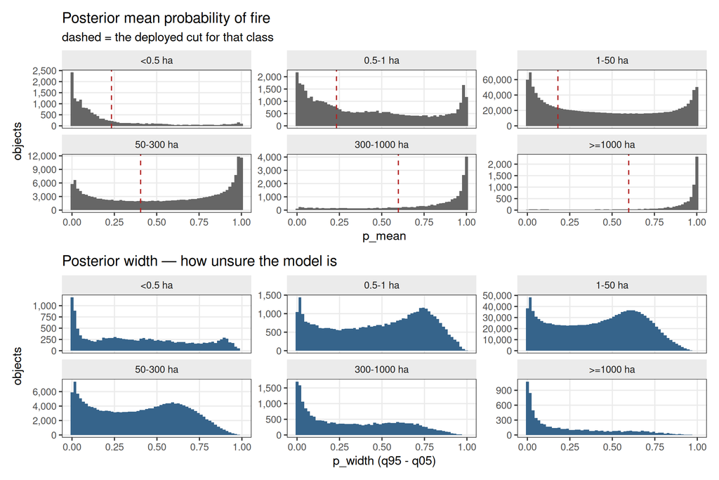

```r
dd <- d[!is.na(p_mean)]
g1 <- ggplot(dd, aes(p_mean)) +
  geom_histogram(bins = 60, fill = "grey40") +
  geom_vline(aes(xintercept = p_thresh), colour = "firebrick", linetype = 2) +
  facet_wrap(~size_class, scales = "free_y", nrow = 2) +
  scale_y_continuous(labels = scales::comma) +
  labs(x = "p_mean", y = "objects", title = "Posterior mean probability of fire",
       subtitle = "dashed = the deployed cut for that class")
g2 <- ggplot(dd, aes(p_width)) +
  geom_histogram(bins = 60, fill = "steelblue4") +
  facet_wrap(~size_class, scales = "free_y", nrow = 2) +
  scale_y_continuous(labels = scales::comma) +
  labs(x = "p_width (q95 - q05)", y = "objects", title = "Posterior width — how unsure the model is")
g1 / g2
```

### 6.2 Global distributions

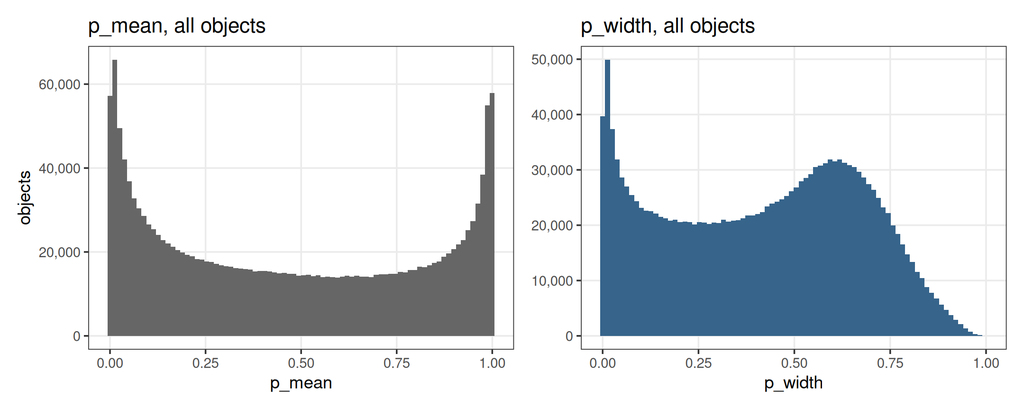

```r
gg1 <- ggplot(dd, aes(p_mean)) + geom_histogram(bins = 80, fill = "grey40") +
  scale_y_continuous(labels = scales::comma) + labs(x = "p_mean", y = "objects", title = "p_mean, all objects")
gg2 <- ggplot(dd, aes(p_width)) + geom_histogram(bins = 80, fill = "steelblue4") +
  scale_y_continuous(labels = scales::comma) + labs(x = "p_width", y = NULL, title = "p_width, all objects")
gg1 + gg2
```

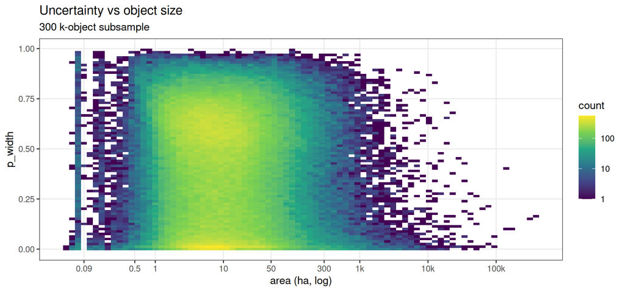

```r
ggplot(dd[sample(.N, min(.N, 300000L))], aes(area_ha, p_width)) +
  geom_bin2d(bins = 80) +
  scale_x_log10(breaks = c(.09, .5, 1, 10, 50, 300, 1e3, 1e4, 1e5),
                labels = c("0.09", "0.5", "1", "10", "50", "300", "1k", "10k", "100k")) +
  scale_fill_viridis_c(trans = "log10", labels = scales::comma) +
  labs(x = "area (ha, log)", y = "p_width", title = "Uncertainty vs object size",
       subtitle = "300 k-object subsample")
```

### 6.3 The minimum-size decision

```r
cuts <- c(0, 0.09, 0.18, 0.5, 1, 2, 5, 10)
ms <- rbindlist(lapply(cuts, function(k) {
  keep <- dd[area_ha >= k]
  drop <- dd[area_ha < k]
  data.table(min_size_ha = k,
             objects_kept   = nrow(keep),
             pct_obj_dropped  = round(100 * nrow(drop) / nrow(dd), 2),
             pct_area_dropped = round(100 * sum(drop$area_ha) / sum(dd$area_ha), 3),
             pct_fire_area_dropped = round(
               100 * sum(drop$area_ha[drop$fire == 1L]) / sum(dd$area_ha[dd$fire == 1L]), 3),
             mean_width_dropped = round(mean(drop$p_width), 3),
             pct_undecided_dropped = round(100 * mean(drop$undecided), 1),
             mean_width_kept = round(mean(keep$p_width), 3),
             pct_undecided_kept = round(100 * mean(keep$undecided), 1))
}))
kable(ms, format.args = list(big.mark = ","),
      caption = "What each candidate minimum size discards, and how uncertain the discarded vs retained objects are.")
```

What each candidate minimum size discards, and how uncertain the discarded vs retained objects are.

| min_size_ha | objects_kept | pct_obj_dropped | pct_area_dropped | pct_fire_area_dropped | mean_width_dropped | pct_undecided_dropped | mean_width_kept | pct_undecided_kept |
| --- | --- | --- | --- | --- | --- | --- | --- | --- |
| 0.00 | 1,689,383 | 0.00 | 0.000 | 0.000 | NaN | NaN | 0.415 | 46.3 |
| 0.09 | 1,685,604 | 0.22 | 0.000 | 0.000 | 0.417 | 65.3 | 0.415 | 46.2 |
| 0.18 | 1,683,028 | 0.38 | 0.001 | 0.000 | 0.400 | 62.0 | 0.415 | 46.2 |
| 0.50 | 1,674,313 | 0.89 | 0.005 | 0.002 | 0.395 | 58.8 | 0.415 | 46.2 |
| 1.00 | 1,631,799 | 3.41 | 0.044 | 0.033 | 0.455 | 58.4 | 0.413 | 45.8 |
| 2.00 | 1,476,460 | 12.60 | 0.321 | 0.285 | 0.454 | 54.0 | 0.409 | 45.1 |
| 5.00 | 1,115,186 | 33.99 | 1.749 | 1.542 | 0.435 | 50.6 | 0.405 | 44.1 |
| 10.00 | 796,965 | 52.83 | 4.452 | 3.939 | 0.426 | 48.9 | 0.402 | 43.3 |

Read this table as a trade: a cut is *cheap* when `pct_area_dropped` is small, and *justified* when `mean_width_dropped` / `pct_undecided_dropped` are clearly worse than the retained set — i.e. we are discarding precisely the objects the model cannot classify.

## 7 · Notes

- `% called fire` figures inherit the threshold-level caveat from docs/06: the labels are not a random sample of objects, so the *level* of the small-object cuts is uncalibrated and these percentages are an upper bound on plausible fire rates, not an estimate of them.
- Objects with NA predictors (all-dieback, docs/05 §3) carry NA probabilities and are excluded from §6 counts but present in §1-4.